# R Notebook

Author

Ayesha Zafar

Published

December 13, 2024

# Final Project

## Package and Data Load

The covid_deaths data frame includes data extracted from Oxford, it includes Time series data from Jan 1, 2020 to December 31 2023. Link to Data: https://ourworldindata.org/covid-deaths

Here is a link to the codebook explaining all the variables used: https://github.com/OxCGRT/covid-policy-dataset/blob/main/documentation_and_codebook.md

The covid_stringency is raw data extracted from the git-hub repository of Oxford. Link to Data: https://github.com/OxCGRT/covid-policy-tracker/tree/master/data

The income_categories data frame includes data extracted from the World Bank, they categorize world countries in High-income, Low-Income, Lower-Middle-Income and Higher-Middle-Income countries. Link to Data: https://datahelpdesk.worldbank.org/knowledgebase/articles/906519-world-bank-country-and-lending-groups

The world_map data frame is extract a data set pre-existing in R that has longitudes and latitudes for the world map.

```r
library("tidyverse")
library("lubridate")
library("dplyr")
library("broom")
library("dlnm")
library("maps")
library("ggplot2")
library("mapdata")
library("knitr")
library("kableExtra")
covid_deaths <-
  read_csv("covid_death.csv")
covid_stringency <-
  readxl::read_excel("covid_stringency_raw.xlsx")

income_categories <-
  read_csv("world-bank-income-groups.csv")
world_map <-
  map_data("world")
```

## Filtering and Cleaning the Data

```r
#The location variable includes world and continent level variables that was skewing the graph, creating this to filter out these observations. This is only true for Covid_deaths, Covid_stringency is raw data.
covid_combined_data <-
  c("World", "Asia", "Europe", "Africa", "North America", "South America", "European Union (27)", "Low-income countries", "Upper-middle-income countries", "High-income countries", "Oceania", "Lower-middle-income countries")


covid_deaths_filtered <-
  covid_deaths %>%
  filter(!location %in% covid_combined_data) %>%  #filtering out aggregated data
  select(location,
         date,
         stringency_index,
         new_cases,
         new_cases_smoothed,
         new_deaths,
         new_deaths_smoothed,
         new_vaccinations_smoothed,
         population_density) %>% #selecting only variables we are using to clean the data
  mutate(date = ymd(date))  %>% #changed the structure of date from string to date format
  drop_na(new_cases_smoothed,
          new_deaths_smoothed,
          new_vaccinations_smoothed) #dropping NA values

#Saving all the excess variables we want to drop to make the code easier to read
drop_columns <-
  c("RegionName", "RegionCode", "C1M_Flag", "C2M_Flag", "C3M_Flag", "C4M_Flag", "C5M_Flag", "C6M_Flag", "C7M_Flag", "E1_Flag","H1_Flag","H6M_Flag","H7_Flag","H8M_Flag", "M1_Wildcard", "V2B", "V2C", "V2D", "V2E", "V2F", "V2G", "V3G", "V3" )

covid_stringency_filtered <-
  covid_stringency %>%
  select(-contains(drop_columns)) %>% #selecting only variables we are using to clean the data
  mutate(date = ymd(Date)) %>% #changed the structure of date from string to date format
  rename_with(~ gsub(" ", "_",.), #variables had spaces in them, replacing with _ to avoid errors
              everything()) %>%
  rename("location" = "CountryName") %>%
  full_join(covid_deaths_filtered,
            by = c("location", "date")) %>%
  mutate(across(c(
    C1M_School_closing,
    C2M_Workplace_closing,
    C3M_Cancel_public_events,
    C4M_Restrictions_on_gatherings,
    C5M_Close_public_transport,
    C6M_Stay_at_home_requirements,
    H1_Public_information_campaigns,
    C7M_Restrictions_on_internal_movement,
    C8EV_International_travel_controls,
    `V4_Mandatory_Vaccination_(summary)`,
    E1_Income_support),
  as.factor)) # Factoring these becayse they are  all ordinal variables according to the code book, but were saved as numerical.
```

## Calculating Stringency Levels

We are assigning each country a Stringency Level: High, Medium, Low.

We categorized them using percentiles, countries that fell below the 25th percentile were assigned to Low Stringency, countries between the 25th and 75th percentile were assigned to Medium Stringency and countries above the 75th percentile were assigned to High Stringency.

```r
#calculating Avg stringency over the 3 years to categorize countries
avg_stringency_calc <-
  covid_deaths_filtered %>%
  group_by(location) %>%
  drop_na(stringency_index) %>%
  summarize(avg_stringency = mean(stringency_index,
                                  rm.na = TRUE))

#finding percentiles for Avg Stringency
low_threshold <-
  quantile(avg_stringency_calc$avg_stringency,
                          0.25)
high_threshold <-
  quantile(avg_stringency_calc$avg_stringency,
                           0.75)

#using the percentiles to assign countries stringency level
avg_stringency_calc <-
  avg_stringency_calc %>%
  mutate(stringency_level = case_when(
    avg_stringency >= high_threshold ~ "High Stringency",
    avg_stringency >= low_threshold ~ "Medium Stringency",
    TRUE ~ "Low Stringency")) %>%
  mutate(stringency_level = factor(stringency_level, levels = c("High Stringency", "Medium Stringency", "Low Stringency"))) %>%
  rename("id" = "location")
```

## World Map Graphs

Creating a Map to visualize Stringency level across the world. First some data cleaning to create a consolidated map dataset.

```r
#found long and lat data for countries
world_map <-
  world_map %>%
  rename(id = region,
         x = long,
         y = lat) %>%
  mutate(id = case_when(
    id == "USA" ~ "United States",
    id == "UK" ~ "United Kingdom",
    id == "Democratic Republic of the Congo" ~ "Democratic Republic of Congo",
    id == "Republic of Congo" ~ "Congo",
    id == "Ivory Coast" ~ "Cote d'Ivoire",
    id == "Czech Republic" ~ "Czechia",
    TRUE ~ id
  )) #There were discrepancies in country names between world map data and our data set, so fixed those so all countries with data are properly mapped

#Combining the stringency_levels back into mapping data set.
world_map <-
  world_map %>%
  inner_join(avg_stringency_calc, by = "id")

#countries that had NA values were not being mapped, so we created a complete list of all countries, and then joined with the stringency calculation so the data set records countries with NA values. This allowed the map to record those without data in grey rather than being left blank
countries_list <-
  world_map %>%
  group_by(id) %>%
  select(id) %>%
  distinct(id)

world_map<-
  countries_list %>%
  left_join(world_map,
            by = "id")
```

### Stringency Map

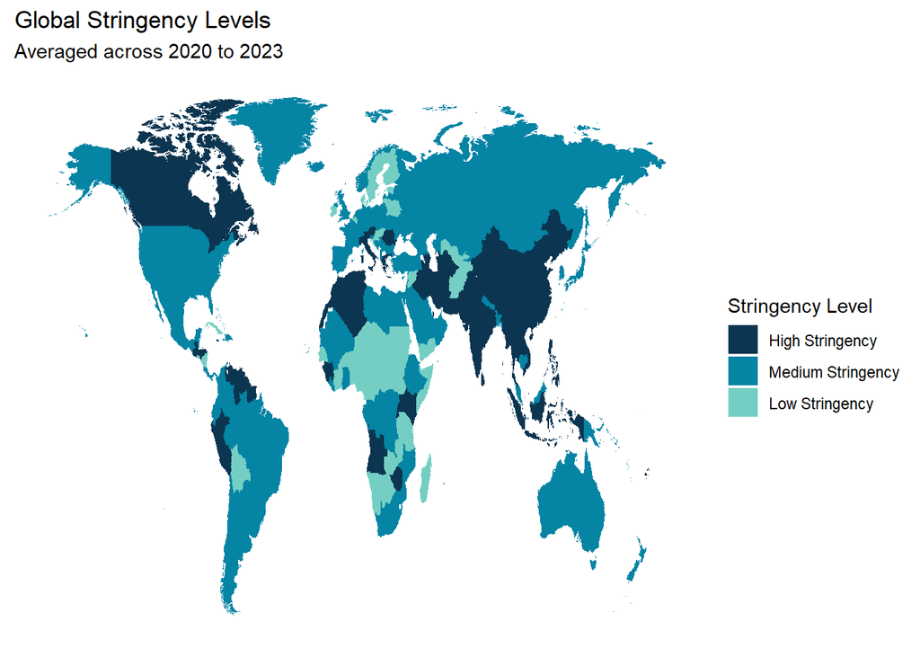

```r
world_map %>%
  ggplot() +
  geom_map(aes(map_id = id,
               fill = stringency_level),
           map = world_map) +
  expand_limits(x = world_map$x ,
                y = world_map$y) +
  scale_fill_manual(
     values = c("Low Stringency" = "#74cec4",
                "Medium Stringency" = "#0584a4",
                "High Stringency" = "#0b3550"),
     limits = c("High Stringency",
                "Medium Stringency",
                "Low Stringency"),
    na.value = "darkgrey",
    name = "Stringency Level"
  ) +
  theme_bw() +
  theme( #cleaning up the graph
    axis.title = element_blank(),
    axis.text = element_blank(),
    axis.ticks = element_blank(),
    panel.grid = element_blank(),
    panel.border = element_blank()
  ) +
  labs(
    title = "Global Stringency Levels",
    subtitle = "Averaged across 2020 to 2023",
    x = "",
    y = ""
  )
```

## Categorizing High and Low Income Countries

We are aware that the existing data set extracted from Oxford does aggregate High and Low income countries. However, it was unclear how this was categorized, therefore we decided to categorize these countries ourself using World Banks methodology.

Here is how the World Bank has catagorized the countries. * Low-income countries are those with a gross national income (GNI) per capita of $1,145 or less in 2023. * Lower-middle-income countries are those with a GNI per capita between $1,146 and 4,515 in 2023. * Upper-middle-income countries are those with a GNI per capita between $4,516 and 14,005 in 2023. * High-income countries are those with a GNI per capita of more than $14,005 in 2023.

For the preliminary analysis, we used 2020 as the base year in categorizing the countries.

```r
#combing income level data with mapping data

world_map <-
  income_categories %>%
  rename(id = Entity, income_level = `World Bank's income classification`) %>%
  filter(Year == 2020) %>%
  select(-Year) %>%
  right_join(world_map, by = "id")
```

Creating a Map to visualize income level across the world.

### Income Group Map

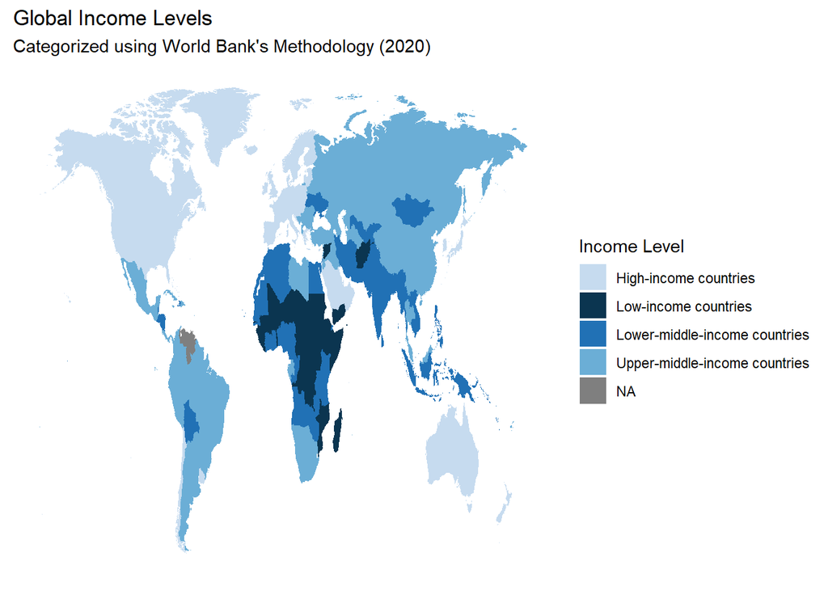

```r
world_map %>%
  ggplot(aes(map_id = id, fill = income_level)) +
  geom_map(map = world_map) +
  expand_limits(x = world_map$x, y = world_map$y) +
  scale_fill_manual(
    values = c("Low-income countries" = "#0b3550",
               "Lower-middle-income countries" = "#2171B5",
               "Upper-middle-income countries" = "#6BAED6",
               "High-income countries" = "#C6DBEF"),
    na.value = "grey50",
    name = "Income Level"
  ) +
  theme_bw() +
  theme(
    axis.title = element_blank(),
    axis.text = element_blank(),
    axis.ticks = element_blank(),
    panel.grid = element_blank(),
    panel.border = element_blank()
  ) +
  labs(
    title = "Global Income Levels",
    subtitle = "Categorized using World Bank's Methodology (2020)",
    x = "",
    y = ""
  )
```

## Descriptive Graphs

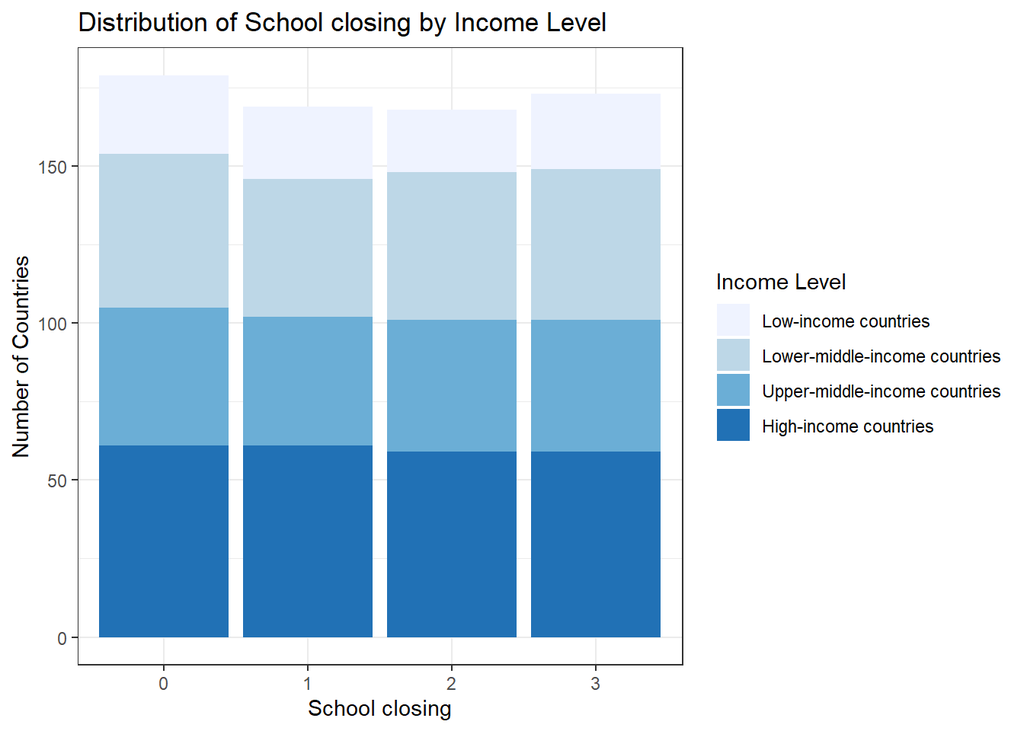

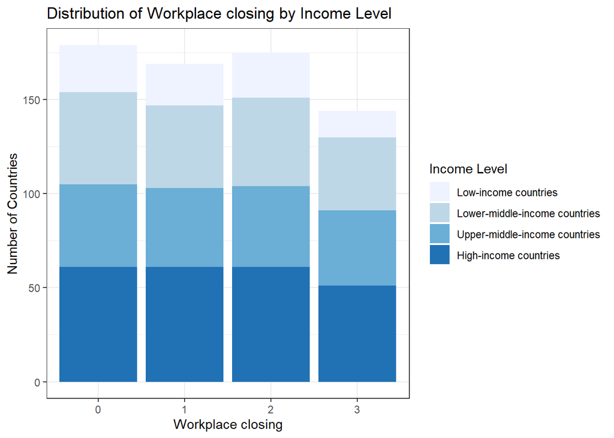

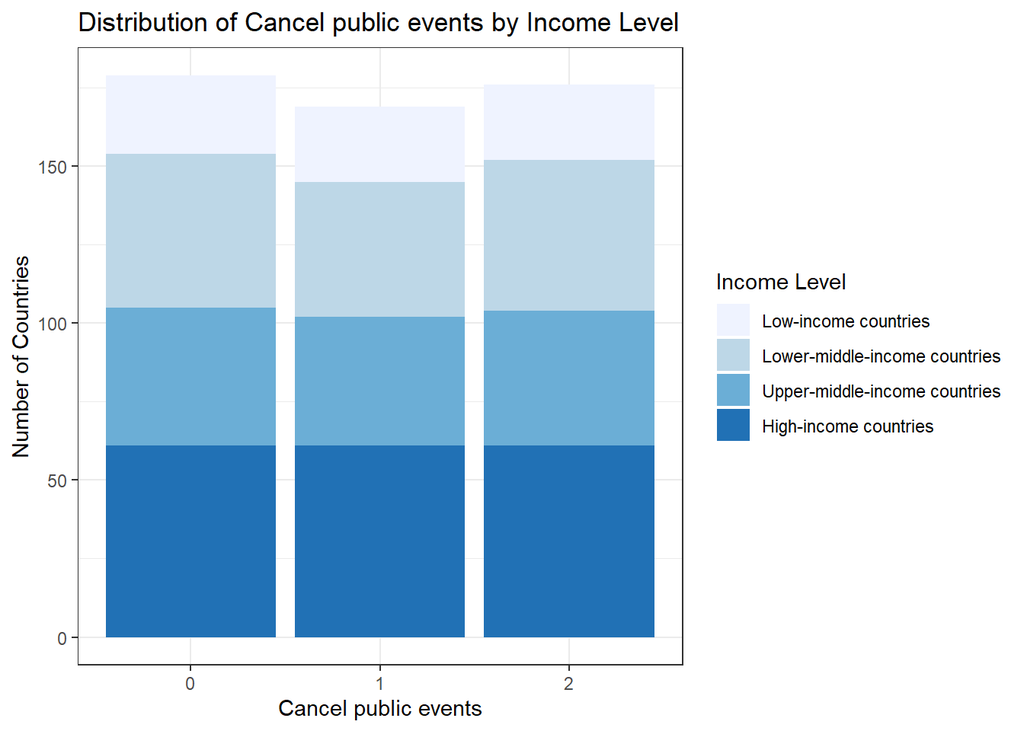

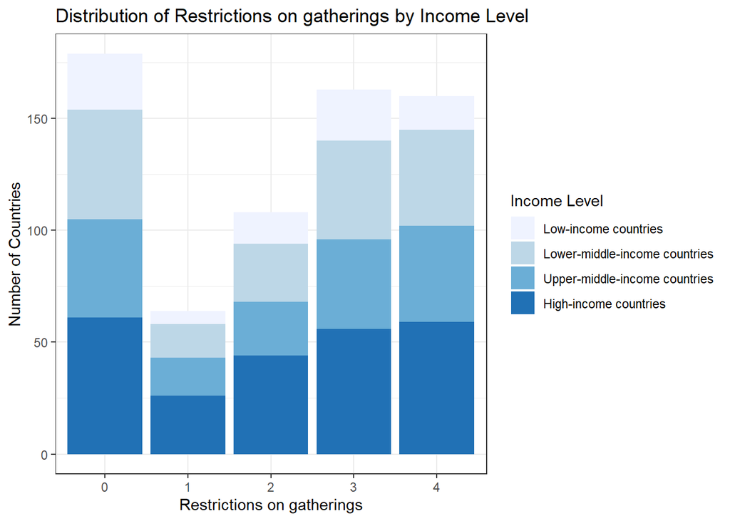

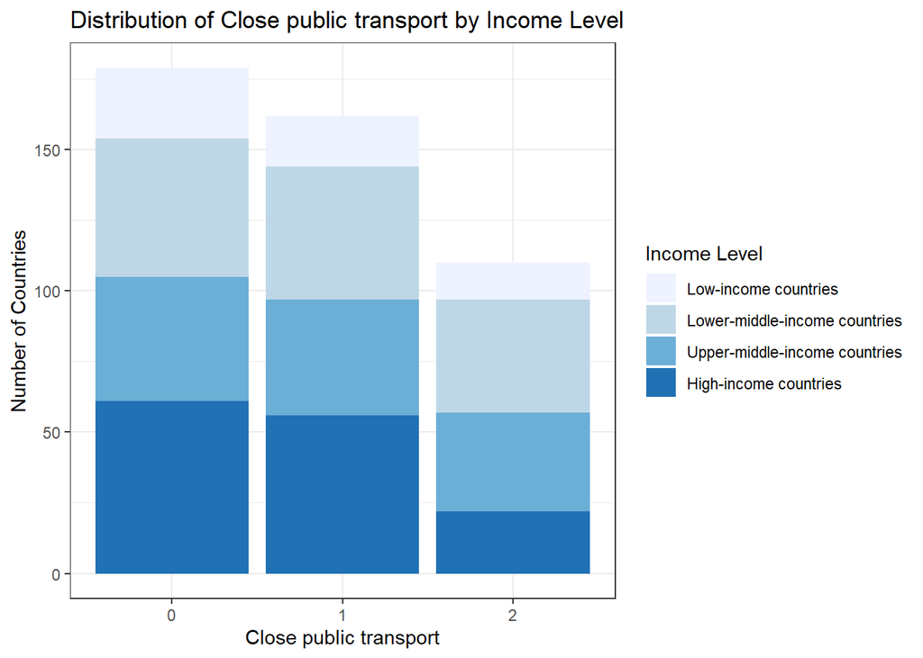

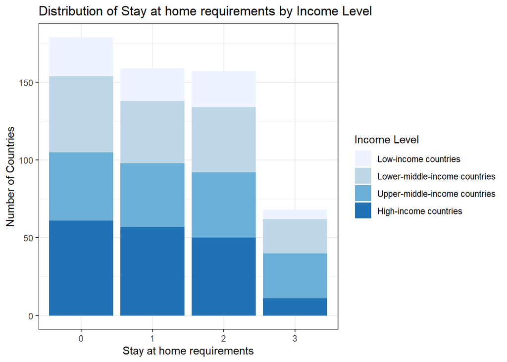

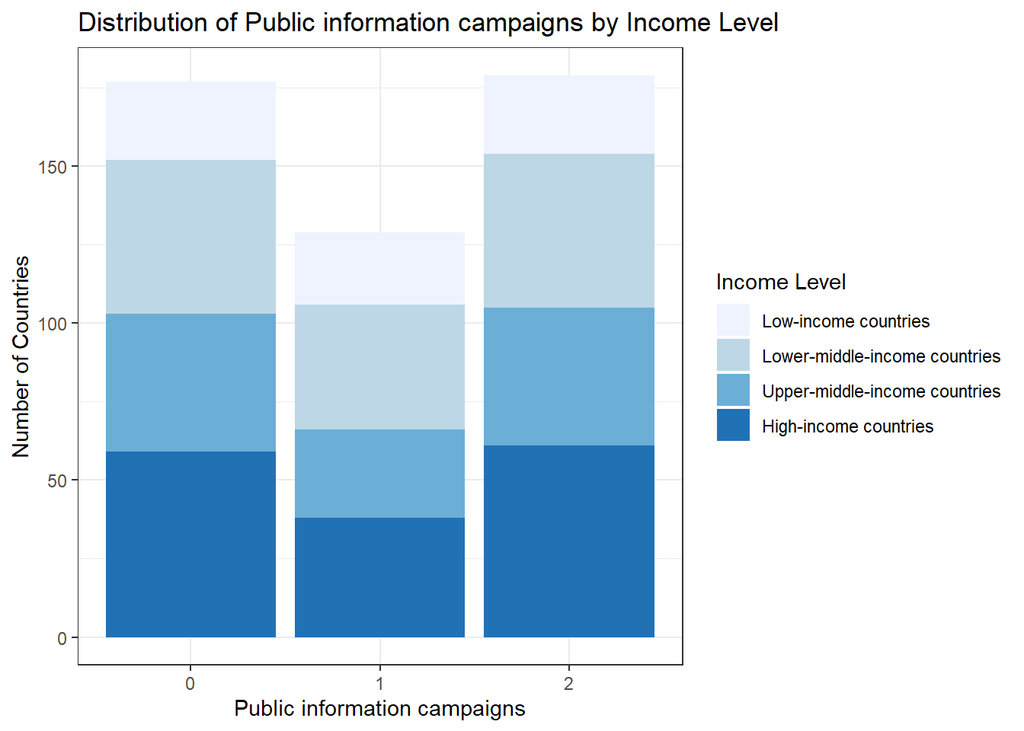

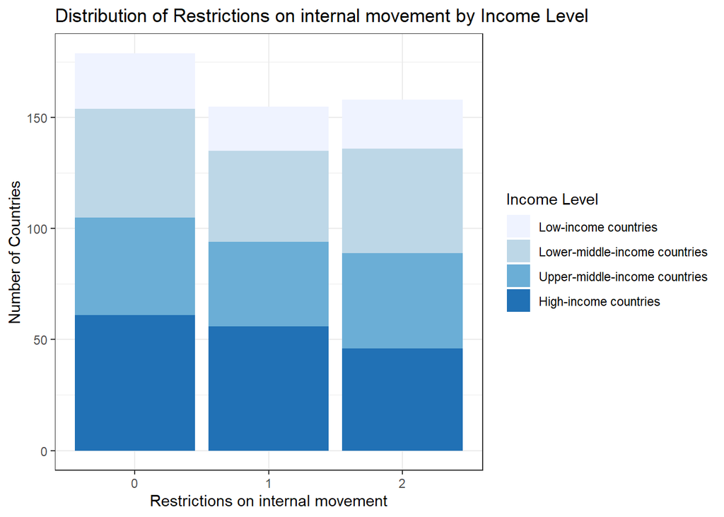

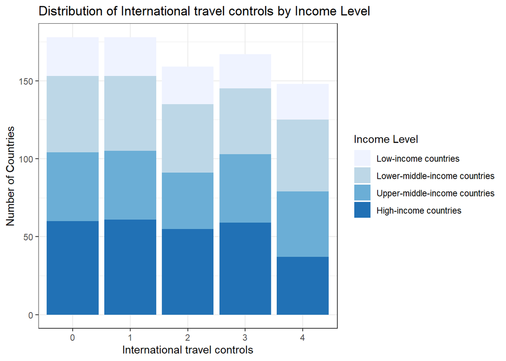

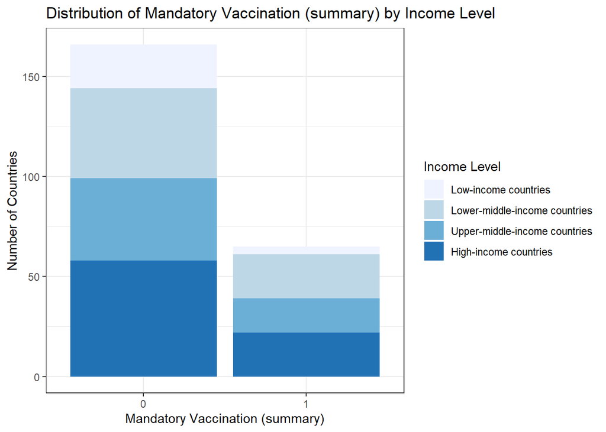

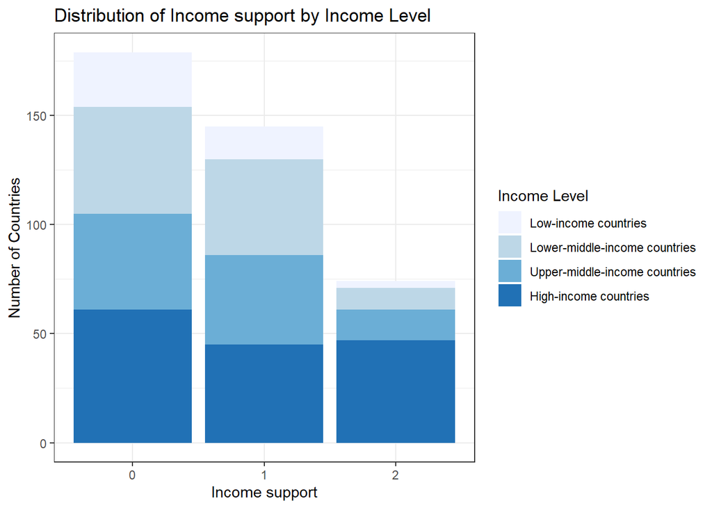

```r
#joining income data with stringency data

covid_stringency_filtered <-
  income_categories %>%
  rename(location = Entity, income_level = `World Bank's income classification`) %>% # Renaming columns for clarity
  filter(Year == 2020) %>%
  select(-Year) %>% #cleaning unwanted variables
  right_join(covid_stringency_filtered, by = "location")

# Function to plot bar graphs

plot_bar_graph <- function(data,
                           income_var,
                           cat_variable,
                           country_var,
                           title = "Distribution by Income Level",
                           x_label = "Category",
                           y_label = "Number of Countries") {

  data_grouped <-
  data %>%
  filter(!is.na({{income_var}}),
         !is.na({{cat_variable}})) %>%
  group_by({{income_var}},
           {{cat_variable}}) %>%
  summarise(
    country_count = n_distinct({{country_var}}),  # Count distinct countries
    .groups = "drop") %>%
  mutate({{income_var}} := factor({{income_var}},
                               levels = c("Low-income countries",
                                          "Lower-middle-income countries",
                                          "Upper-middle-income countries",
                                          "High-income countries")),
         {{cat_variable}} := factor({{cat_variable}}))


plot <-
  data_grouped %>%
  ggplot(aes(x = {{cat_variable}}, y = country_count, fill = {{income_var}})) +
  geom_bar(stat = "identity") +
  scale_fill_brewer(palette = "Blues") +  # Optional: Set a color palette
  labs(
    title = title,
    x = x_label,
    y = y_label,
    fill = "Income Level"
  ) +
  theme_bw()

return(plot)

}

# Function to clean variable names for graph titles
clean_variable_name <- function(var_name) {
  # Remove the leading codes (before the first underscore) and replace underscores with spaces
  cleaned_name <- gsub("^[A-Za-z0-9]+_", "", var_name)  # Remove code part at the start
  cleaned_name <- gsub("_", " ", cleaned_name)  # Replace underscores with spaces
  return(cleaned_name)
}


# List of variables to plot
variables <- c(
  "C1M_School_closing",
  "C2M_Workplace_closing",
  "C3M_Cancel_public_events",
  "C4M_Restrictions_on_gatherings",
  "C5M_Close_public_transport",
  "C6M_Stay_at_home_requirements",
  "H1_Public_information_campaigns",
  "C7M_Restrictions_on_internal_movement",
  "C8EV_International_travel_controls",
  "V4_Mandatory_Vaccination_(summary)",
  "E1_Income_support"
)

# Loop to create and print the plots for all variables in the list
for (var in variables) {

  clean_title <- clean_variable_name(var)

  plot <- plot_bar_graph(
    data = covid_stringency_filtered,
    income_var = income_level,
    country_var = location,
    cat_variable = !!sym(var),  # Dynamically get the variable name
    title = paste("Distribution of", clean_title, "by Income Level"),
    x_label = clean_title,
    y_label = "Number of Countries"
  )

  print(plot)
}
```

#Testing for Multicollinearity This code is testing for multicollinearity by computing correlation matrices to show the relationships between variables.

```r
colnames(covid_stringency_filtered)
```

```
 [1] "location"
 [2] "Code"
 [3] "income_level"
 [4] "CountryCode"
 [5] "Jurisdiction"
 [6] "Date"
 [7] "C1M_School_closing"
 [8] "C2M_Workplace_closing"
 [9] "C3M_Cancel_public_events"
[10] "C4M_Restrictions_on_gatherings"
[11] "C5M_Close_public_transport"
[12] "C6M_Stay_at_home_requirements"
[13] "C7M_Restrictions_on_internal_movement"
[14] "C8EV_International_travel_controls"
[15] "E1_Income_support"
```

[output cut: 34 more lines]

```r
# Setting random seed for reproducibility of results
set.seed(22121998)


#selecting all of the Independant variables
numeric_vars <- covid_stringency_filtered[, c("C1M_School_closing",
                                              "C2M_Workplace_closing",
                                              "C3M_Cancel_public_events",
                                              "C4M_Restrictions_on_gatherings",
                                              "C5M_Close_public_transport",
                                              "C6M_Stay_at_home_requirements",
                                              "H1_Public_information_campaigns",
                                              "C7M_Restrictions_on_internal_movement",
                                              "C8EV_International_travel_controls",
                                              "V4_Mandatory_Vaccination_(summary)",
                                              "H4_Emergency_investment_in_healthcare",
                                              "new_vaccinations_smoothed",
                                              "E1_Income_support"
                                              )]

numeric_vars <- numeric_vars %>%
  mutate(across(everything(), ~ as.numeric(as.character(.))))

# Compute correlation matrix
cor_matrix <- cor(numeric_vars, use = "complete.obs")
print(cor_matrix)
```

```
                                      C1M_School_closing C2M_Workplace_closing
C1M_School_closing                           1.000000000            0.53672755
C2M_Workplace_closing                        0.536727548            1.00000000
C3M_Cancel_public_events                     0.492089449            0.59846213
C4M_Restrictions_on_gatherings               0.430045872            0.51219522
C5M_Close_public_transport                   0.347818827            0.41917943
C6M_Stay_at_home_requirements                0.472111201            0.46176230
H1_Public_information_campaigns              0.069007682            0.10694580
C7M_Restrictions_on_internal_movement        0.401122350            0.50180846
C8EV_International_travel_controls           0.145625865            0.14624862
V4_Mandatory_Vaccination_(summary)           0.171466896            0.20124361
H4_Emergency_investment_in_healthcare        0.003104055            0.01987948
new_vaccinations_smoothed                    0.099530629            0.13495942
E1_Income_support                            0.201800475            0.32747190
                                      C3M_Cancel_public_events
C1M_School_closing                                 0.492089449
C2M_Workplace_closing                              0.598462130
C3M_Cancel_public_events                           1.000000000
C4M_Restrictions_on_gatherings                     0.598973477
C5M_Close_public_transport                         0.309908705
C6M_Stay_at_home_requirements                      0.324077851
H1_Public_information_campaigns                    0.035624726
C7M_Restrictions_on_internal_movement              0.462120350
C8EV_International_travel_controls                 0.018993178
V4_Mandatory_Vaccination_(summary)                 0.123633932
H4_Emergency_investment_in_healthcare              0.009909509
new_vaccinations_smoothed                          0.080505185
E1_Income_support                                  0.113653863
                                      C4M_Restrictions_on_gatherings
C1M_School_closing                                        0.43004587
C2M_Workplace_closing                                     0.51219522
C3M_Cancel_public_events                                  0.59897348
C4M_Restrictions_on_gatherings                            1.00000000
C5M_Close_public_transport                                0.39599481
C6M_Stay_at_home_requirements                             0.33697693
H1_Public_information_campaigns                           0.22694705
C7M_Restrictions_on_internal_movement                     0.37225819
C8EV_International_travel_controls                        0.14738049
V4_Mandatory_Vaccination_(summary)                        0.05478745
H4_Emergency_investment_in_healthcare                     0.01086453
```

[output cut: 113 more lines]

```
E1_Income_support                                  0.0502878850
                                      E1_Income_support
C1M_School_closing                         0.2018004747
C2M_Workplace_closing                      0.3274719009
C3M_Cancel_public_events                   0.1136538630
C4M_Restrictions_on_gatherings             0.2609943046
C5M_Close_public_transport                 0.1295160951
C6M_Stay_at_home_requirements              0.1270648952
H1_Public_information_campaigns            0.2312470245
C7M_Restrictions_on_internal_movement      0.0767959524
C8EV_International_travel_controls        -0.0079739287
V4_Mandatory_Vaccination_(summary)        -0.1602900614
H4_Emergency_investment_in_healthcare     -0.0002006699
new_vaccinations_smoothed                  0.0502878850
E1_Income_support                          1.0000000000
```

```r
#creating a pretty table
cor_matrix_df <- as.data.frame(cor_matrix)  # Convert to data.frame for easy display
kable(cor_matrix_df, caption = "Correlation Matrix for Stringency Measures", digits = 2)
```

Correlation Matrix for Stringency Measures

|  | C1M_School_closing | C2M_Workplace_closing | C3M_Cancel_public_events | C4M_Restrictions_on_gatherings | C5M_Close_public_transport | C6M_Stay_at_home_requirements | H1_Public_information_campaigns | C7M_Restrictions_on_internal_movement | C8EV_International_travel_controls | V4_Mandatory_Vaccination_(summary) | H4_Emergency_investment_in_healthcare | new_vaccinations_smoothed | E1_Income_support |
| --- | --- | --- | --- | --- | --- | --- | --- | --- | --- | --- | --- | --- | --- |
| C1M_School_closing | 1.00 | 0.54 | 0.49 | 0.43 | 0.35 | 0.47 | 0.07 | 0.40 | 0.15 | 0.17 | 0.00 | 0.10 | 0.20 |
| C2M_Workplace_closing | 0.54 | 1.00 | 0.60 | 0.51 | 0.42 | 0.46 | 0.11 | 0.50 | 0.15 | 0.20 | 0.02 | 0.13 | 0.33 |
| C3M_Cancel_public_events | 0.49 | 0.60 | 1.00 | 0.60 | 0.31 | 0.32 | 0.04 | 0.46 | 0.02 | 0.12 | 0.01 | 0.08 | 0.11 |
| C4M_Restrictions_on_gatherings | 0.43 | 0.51 | 0.60 | 1.00 | 0.40 | 0.34 | 0.23 | 0.37 | 0.15 | 0.05 | 0.01 | 0.11 | 0.26 |
| C5M_Close_public_transport | 0.35 | 0.42 | 0.31 | 0.40 | 1.00 | 0.34 | 0.13 | 0.41 | 0.26 | 0.06 | 0.01 | 0.09 | 0.13 |
| C6M_Stay_at_home_requirements | 0.47 | 0.46 | 0.32 | 0.34 | 0.34 | 1.00 | 0.07 | 0.44 | 0.12 | 0.13 | 0.01 | 0.20 | 0.13 |
| H1_Public_information_campaigns | 0.07 | 0.11 | 0.04 | 0.23 | 0.13 | 0.07 | 1.00 | 0.06 | 0.06 | 0.06 | 0.00 | 0.04 | 0.23 |
| C7M_Restrictions_on_internal_movement | 0.40 | 0.50 | 0.46 | 0.37 | 0.41 | 0.44 | 0.06 | 1.00 | 0.25 | 0.31 | 0.02 | 0.14 | 0.08 |
| C8EV_International_travel_controls | 0.15 | 0.15 | 0.02 | 0.15 | 0.26 | 0.12 | 0.06 | 0.25 | 1.00 | 0.13 | 0.01 | 0.08 | -0.01 |
| V4_Mandatory_Vaccination_(summary) | 0.17 | 0.20 | 0.12 | 0.05 | 0.06 | 0.13 | 0.06 | 0.31 | 0.13 | 1.00 | 0.03 | -0.03 | -0.16 |
| H4_Emergency_investment_in_healthcare | 0.00 | 0.02 | 0.01 | 0.01 | 0.01 | 0.01 | 0.00 | 0.02 | 0.01 | 0.03 | 1.00 | 0.00 | 0.00 |
| new_vaccinations_smoothed | 0.10 | 0.13 | 0.08 | 0.11 | 0.09 | 0.20 | 0.04 | 0.14 | 0.08 | -0.03 | 0.00 | 1.00 | 0.05 |
| E1_Income_support | 0.20 | 0.33 | 0.11 | 0.26 | 0.13 | 0.13 | 0.23 | 0.08 | -0.01 | -0.16 | 0.00 | 0.05 | 1.00 |

## Cases Regression Model

```r
# Step 1: Lag the dependent and independent variables
covid_data_lagged <- covid_stringency_filtered %>%
  mutate(
    lag_covid_deaths = lag(new_deaths_smoothed, 14),
    lag_covid_cases = lag(new_cases_smoothed, 14),  # 14-day lag for dependent variable
    lag_C1M_School_closing = lag(C1M_School_closing, 21),
    lag_C2M_Workplace_closing = lag(C2M_Workplace_closing, 21),
    lag_C3M_Cancel_public_events = lag(C3M_Cancel_public_events, 21),
    lag_C4M_Restrictions_on_gatherings = lag(C4M_Restrictions_on_gatherings, 21),
    lag_C5M_Close_public_transport = lag(C5M_Close_public_transport, 21),
    lag_C6M_Stay_at_home_requirements = lag(C6M_Stay_at_home_requirements, 21),
    lag_H1_Public_information_campaigns = lag(H1_Public_information_campaigns, 21),
    lag_C7M_Restrictions_on_internal_movement = lag(C7M_Restrictions_on_internal_movement, 21),
    lag_C8EV_International_travel_controls = lag(C8EV_International_travel_controls, 21),
    lag_V4_Mandatory_Vaccination = lag(`V4_Mandatory_Vaccination_(summary)`, 21),
    lag_covid_vaccines = lag(new_vaccinations_smoothed, 21),
    lag_healthcare_infrastructure = lag(H4_Emergency_investment_in_healthcare, 21),
    lag_income_support = lag(E1_Income_support, 21)
  )

# Step 2: Remove rows with NA values caused by lagging
covid_data_lagged <- covid_data_lagged %>% drop_na()

# Step 3: Fit the regression model
reg_model_cases <- lm(
  new_cases_smoothed ~ lag_covid_cases +
    lag_C1M_School_closing +
    lag_C2M_Workplace_closing +
    lag_C3M_Cancel_public_events +
    lag_C4M_Restrictions_on_gatherings +
    lag_C5M_Close_public_transport +
    lag_C6M_Stay_at_home_requirements +
    lag_H1_Public_information_campaigns +
    lag_C7M_Restrictions_on_internal_movement +
    lag_C8EV_International_travel_controls +
    lag_covid_vaccines +
    lag_income_support +
    lag_healthcare_infrastructure +
    population_density,
  data = covid_data_lagged
)

# Step 4: View the regression summary
summary(reg_model_cases)
```

```
Call:
lm(formula = new_cases_smoothed ~ lag_covid_cases + lag_C1M_School_closing +
    lag_C2M_Workplace_closing + lag_C3M_Cancel_public_events +
    lag_C4M_Restrictions_on_gatherings + lag_C5M_Close_public_transport +
    lag_C6M_Stay_at_home_requirements + lag_H1_Public_information_campaigns +
    lag_C7M_Restrictions_on_internal_movement + lag_C8EV_International_travel_controls +
    lag_covid_vaccines + lag_income_support + lag_healthcare_infrastructure +
    population_density, data = covid_data_lagged)

Residuals:
   Min     1Q Median     3Q    Max
-40786   -798   -241    441  72419

Coefficients:
                                             Estimate Std. Error t value
(Intercept)                                 6.360e+02  4.712e+02   1.350
lag_covid_cases                             8.465e-01  3.804e-03 222.548
lag_C1M_School_closing1                     2.109e+02  4.406e+02   0.479
lag_C1M_School_closing2                     1.297e+02  4.421e+02   0.293
lag_C1M_School_closing3                     6.627e+02  4.493e+02   1.475
lag_C2M_Workplace_closing1                  2.595e+01  4.753e+02   0.055
lag_C2M_Workplace_closing2                  1.239e+02  4.642e+02   0.267
lag_C2M_Workplace_closing3                 -1.372e+03  5.585e+02  -2.456
lag_C3M_Cancel_public_events1              -9.536e+01  5.399e+02  -0.177
lag_C3M_Cancel_public_events2              -2.136e+02  5.709e+02  -0.374
lag_C4M_Restrictions_on_gatherings1         1.756e+02  1.121e+03   0.157
lag_C4M_Restrictions_on_gatherings2         4.755e+02  5.426e+02   0.876
lag_C4M_Restrictions_on_gatherings3         2.564e+02  4.791e+02   0.535
lag_C4M_Restrictions_on_gatherings4         5.635e+02  4.975e+02   1.133
lag_C5M_Close_public_transport1             2.580e+02  1.905e+02   1.355
lag_C5M_Close_public_transport2            -6.608e+02  3.628e+02  -1.821
lag_C6M_Stay_at_home_requirements1         -2.405e+02  2.413e+02  -0.997
lag_C6M_Stay_at_home_requirements2         -5.957e+02  2.264e+02  -2.631
lag_C6M_Stay_at_home_requirements3          1.946e+03  4.933e+02   3.946
lag_H1_Public_information_campaigns2       -1.189e+03  4.054e+02  -2.932
lag_C7M_Restrictions_on_internal_movement1 -2.913e+02  2.389e+02  -1.219
lag_C7M_Restrictions_on_internal_movement2  1.311e+02  2.301e+02   0.570
lag_C8EV_International_travel_controls2    -4.123e+01  2.369e+02  -0.174
lag_C8EV_International_travel_controls3     1.013e+03  2.317e+02   4.374
lag_C8EV_International_travel_controls4     3.116e+02  3.101e+02   1.005
```

[output cut: 27 more lines]

```
lag_C7M_Restrictions_on_internal_movement2 0.568897
lag_C8EV_International_travel_controls2    0.861824
lag_C8EV_International_travel_controls3    1.24e-05 ***
lag_C8EV_International_travel_controls4    0.314978
lag_covid_vaccines                         0.000119 ***
lag_income_support1                        0.140405
lag_income_support2                        0.787145
lag_healthcare_infrastructure              0.563840
population_density                         0.094030 .
---
Signif. codes:  0 '***' 0.001 '**' 0.01 '*' 0.05 '.' 0.1 ' ' 1

Residual standard error: 5259 on 5338 degrees of freedom
Multiple R-squared:  0.9237,    Adjusted R-squared:  0.9233
F-statistic:  2228 on 29 and 5338 DF,  p-value: < 2.2e-16
```

```r
tidy(reg_model_cases) %>%
  kable(digits = 3, caption = "Regression Model: New Cases Smoothed vs. Various Predictors") %>%
  kable_styling(bootstrap_options = c("striped", "hover", "condensed"), full_width = F) %>%
  column_spec(1, bold = TRUE) %>%
  column_spec(2:5, color = "blue")
```

Regression Model: New Cases Smoothed vs. Various Predictors

| term | estimate | std.error | statistic | p.value |
| --- | --- | --- | --- | --- |
| (Intercept) | 635.966 | 471.192 | 1.350 | 0.177 |
| lag_covid_cases | 0.846 | 0.004 | 222.548 | 0.000 |
| lag_C1M_School_closing1 | 210.881 | 440.617 | 0.479 | 0.632 |
| lag_C1M_School_closing2 | 129.725 | 442.057 | 0.293 | 0.769 |
| lag_C1M_School_closing3 | 662.684 | 449.259 | 1.475 | 0.140 |
| lag_C2M_Workplace_closing1 | 25.949 | 475.340 | 0.055 | 0.956 |
| lag_C2M_Workplace_closing2 | 123.936 | 464.151 | 0.267 | 0.789 |
| lag_C2M_Workplace_closing3 | -1371.709 | 558.469 | -2.456 | 0.014 |
| lag_C3M_Cancel_public_events1 | -95.359 | 539.880 | -0.177 | 0.860 |
| lag_C3M_Cancel_public_events2 | -213.573 | 570.880 | -0.374 | 0.708 |
| lag_C4M_Restrictions_on_gatherings1 | 175.586 | 1120.810 | 0.157 | 0.876 |
| lag_C4M_Restrictions_on_gatherings2 | 475.499 | 542.643 | 0.876 | 0.381 |
| lag_C4M_Restrictions_on_gatherings3 | 256.365 | 479.110 | 0.535 | 0.593 |
| lag_C4M_Restrictions_on_gatherings4 | 563.530 | 497.549 | 1.133 | 0.257 |
| lag_C5M_Close_public_transport1 | 258.013 | 190.450 | 1.355 | 0.176 |
| lag_C5M_Close_public_transport2 | -660.812 | 362.791 | -1.821 | 0.069 |
| lag_C6M_Stay_at_home_requirements1 | -240.545 | 241.253 | -0.997 | 0.319 |
| lag_C6M_Stay_at_home_requirements2 | -595.654 | 226.414 | -2.631 | 0.009 |
| lag_C6M_Stay_at_home_requirements3 | 1946.335 | 493.296 | 3.946 | 0.000 |
| lag_H1_Public_information_campaigns2 | -1188.553 | 405.371 | -2.932 | 0.003 |
| lag_C7M_Restrictions_on_internal_movement1 | -291.281 | 238.890 | -1.219 | 0.223 |
| lag_C7M_Restrictions_on_internal_movement2 | 131.111 | 230.136 | 0.570 | 0.569 |
| lag_C8EV_International_travel_controls2 | -41.232 | 236.882 | -0.174 | 0.862 |
| lag_C8EV_International_travel_controls3 | 1013.433 | 231.692 | 4.374 | 0.000 |
| lag_C8EV_International_travel_controls4 | 311.623 | 310.096 | 1.005 | 0.315 |
| lag_covid_vaccines | 0.000 | 0.000 | -3.851 | 0.000 |
| lag_income_support1 | 331.098 | 224.549 | 1.475 | 0.140 |
| lag_income_support2 | -68.211 | 252.603 | -0.270 | 0.787 |
| lag_healthcare_infrastructure | 0.000 | 0.000 | -0.577 | 0.564 |
| population_density | 0.375 | 0.224 | 1.675 | 0.094 |

## Deaths Regression Model

```r
reg_model_death <- lm(
  new_deaths_smoothed ~ lag_covid_deaths +
    lag_C1M_School_closing +
    lag_C2M_Workplace_closing +
    lag_C3M_Cancel_public_events +
    lag_C4M_Restrictions_on_gatherings +
    lag_C5M_Close_public_transport +
    lag_C6M_Stay_at_home_requirements +
    lag_H1_Public_information_campaigns +
    lag_C7M_Restrictions_on_internal_movement +
    lag_C8EV_International_travel_controls +
    lag_covid_vaccines +
    lag_income_support +
    lag_healthcare_infrastructure +
    population_density,
  data = covid_data_lagged
)

summary(reg_model_death)
```

```
Call:
lm(formula = new_deaths_smoothed ~ lag_covid_deaths + lag_C1M_School_closing +
    lag_C2M_Workplace_closing + lag_C3M_Cancel_public_events +
    lag_C4M_Restrictions_on_gatherings + lag_C5M_Close_public_transport +
    lag_C6M_Stay_at_home_requirements + lag_H1_Public_information_campaigns +
    lag_C7M_Restrictions_on_internal_movement + lag_C8EV_International_travel_controls +
    lag_covid_vaccines + lag_income_support + lag_healthcare_infrastructure +
    population_density, data = covid_data_lagged)

Residuals:
     Min       1Q   Median       3Q      Max
-1092.52   -16.97     0.62    15.06   798.94

Coefficients:
                                             Estimate Std. Error t value
(Intercept)                                -4.373e+00  7.595e+00  -0.576
lag_covid_deaths                            9.130e-01  3.668e-03 248.899
lag_C1M_School_closing1                    -1.500e+00  7.105e+00  -0.211
lag_C1M_School_closing2                    -2.526e+01  7.126e+00  -3.545
lag_C1M_School_closing3                     3.578e+01  7.239e+00   4.943
lag_C2M_Workplace_closing1                  7.192e-01  7.662e+00   0.094
lag_C2M_Workplace_closing2                 -6.462e+00  7.482e+00  -0.864
lag_C2M_Workplace_closing3                 -5.736e+01  8.989e+00  -6.381
lag_C3M_Cancel_public_events1               2.072e+01  8.702e+00   2.381
lag_C3M_Cancel_public_events2               1.412e+01  9.203e+00   1.534
lag_C4M_Restrictions_on_gatherings1        -6.481e-01  1.807e+01  -0.036
lag_C4M_Restrictions_on_gatherings2         6.114e+00  8.746e+00   0.699
lag_C4M_Restrictions_on_gatherings3        -3.785e+00  7.727e+00  -0.490
lag_C4M_Restrictions_on_gatherings4         7.821e+00  8.026e+00   0.974
lag_C5M_Close_public_transport1            -1.593e+00  3.072e+00  -0.518
lag_C5M_Close_public_transport2            -1.172e+00  5.848e+00  -0.200
lag_C6M_Stay_at_home_requirements1         -2.340e+00  3.889e+00  -0.602
lag_C6M_Stay_at_home_requirements2         -3.103e+00  3.656e+00  -0.849
lag_C6M_Stay_at_home_requirements3          3.238e+01  7.954e+00   4.071
lag_H1_Public_information_campaigns2       -1.161e+01  6.535e+00  -1.776
lag_C7M_Restrictions_on_internal_movement1 -1.853e+01  3.851e+00  -4.811
lag_C7M_Restrictions_on_internal_movement2  4.597e+00  3.724e+00   1.234
lag_C8EV_International_travel_controls2     5.782e+00  3.819e+00   1.514
lag_C8EV_International_travel_controls3     1.016e+01  3.731e+00   2.724
lag_C8EV_International_travel_controls4     1.011e+01  5.010e+00   2.018
```

[output cut: 27 more lines]

```
lag_C7M_Restrictions_on_internal_movement2 0.217109
lag_C8EV_International_travel_controls2    0.130058
lag_C8EV_International_travel_controls3    0.006471 **
lag_C8EV_International_travel_controls4    0.043676 *
lag_covid_vaccines                         0.004935 **
lag_income_support1                        0.002752 **
lag_income_support2                        0.007911 **
lag_healthcare_infrastructure              0.759318
population_density                         0.243292
---
Signif. codes:  0 '***' 0.001 '**' 0.01 '*' 0.05 '.' 0.1 ' ' 1

Residual standard error: 84.77 on 5338 degrees of freedom
Multiple R-squared:  0.9388,    Adjusted R-squared:  0.9385
F-statistic:  2824 on 29 and 5338 DF,  p-value: < 2.2e-16
```

```r
tidy(reg_model_death) %>%
  kable(digits = 3, caption = "Regression Model: New Deaths Smoothed vs. Various Predictors") %>%
  kable_styling(bootstrap_options = c("striped", "hover", "condensed"), full_width = F) %>%
  column_spec(1, bold = TRUE) %>%
  column_spec(2:5, color = "blue")
```

Regression Model: New Deaths Smoothed vs. Various Predictors

| term | estimate | std.error | statistic | p.value |
| --- | --- | --- | --- | --- |
| (Intercept) | -4.373 | 7.595 | -0.576 | 0.565 |
| lag_covid_deaths | 0.913 | 0.004 | 248.899 | 0.000 |
| lag_C1M_School_closing1 | -1.500 | 7.105 | -0.211 | 0.833 |
| lag_C1M_School_closing2 | -25.259 | 7.126 | -3.545 | 0.000 |
| lag_C1M_School_closing3 | 35.784 | 7.239 | 4.943 | 0.000 |
| lag_C2M_Workplace_closing1 | 0.719 | 7.662 | 0.094 | 0.925 |
| lag_C2M_Workplace_closing2 | -6.462 | 7.482 | -0.864 | 0.388 |
| lag_C2M_Workplace_closing3 | -57.356 | 8.989 | -6.381 | 0.000 |
| lag_C3M_Cancel_public_events1 | 20.723 | 8.702 | 2.381 | 0.017 |
| lag_C3M_Cancel_public_events2 | 14.117 | 9.203 | 1.534 | 0.125 |
| lag_C4M_Restrictions_on_gatherings1 | -0.648 | 18.067 | -0.036 | 0.971 |
| lag_C4M_Restrictions_on_gatherings2 | 6.114 | 8.746 | 0.699 | 0.485 |
| lag_C4M_Restrictions_on_gatherings3 | -3.785 | 7.727 | -0.490 | 0.624 |
| lag_C4M_Restrictions_on_gatherings4 | 7.821 | 8.026 | 0.974 | 0.330 |
| lag_C5M_Close_public_transport1 | -1.593 | 3.072 | -0.518 | 0.604 |
| lag_C5M_Close_public_transport2 | -1.172 | 5.848 | -0.200 | 0.841 |
| lag_C6M_Stay_at_home_requirements1 | -2.340 | 3.889 | -0.602 | 0.547 |
| lag_C6M_Stay_at_home_requirements2 | -3.103 | 3.656 | -0.849 | 0.396 |
| lag_C6M_Stay_at_home_requirements3 | 32.379 | 7.954 | 4.071 | 0.000 |
| lag_H1_Public_information_campaigns2 | -11.608 | 6.535 | -1.776 | 0.076 |
| lag_C7M_Restrictions_on_internal_movement1 | -18.528 | 3.851 | -4.811 | 0.000 |
| lag_C7M_Restrictions_on_internal_movement2 | 4.597 | 3.724 | 1.234 | 0.217 |
| lag_C8EV_International_travel_controls2 | 5.782 | 3.819 | 1.514 | 0.130 |
| lag_C8EV_International_travel_controls3 | 10.163 | 3.731 | 2.724 | 0.006 |
| lag_C8EV_International_travel_controls4 | 10.109 | 5.010 | 2.018 | 0.044 |
| lag_covid_vaccines | 0.000 | 0.000 | -2.812 | 0.005 |
| lag_income_support1 | 10.846 | 3.621 | 2.996 | 0.003 |
| lag_income_support2 | -10.836 | 4.079 | -2.657 | 0.008 |
| lag_healthcare_infrastructure | 0.000 | 0.000 | -0.306 | 0.759 |
| population_density | 0.004 | 0.004 | 1.167 | 0.243 |

# plotting the reg models

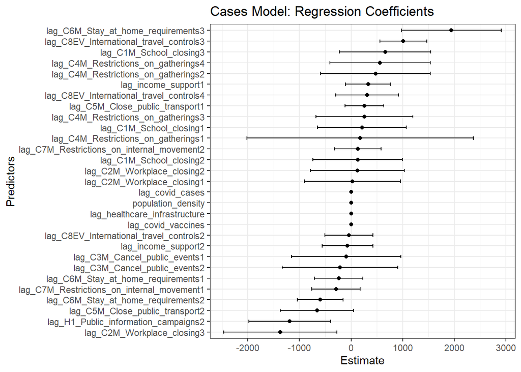

```r
# Extract coefficients
coeffs_cases <- tidy(reg_model_cases, conf.int = TRUE) %>%
  filter(term != "(Intercept)")

# Plot coefficients
ggplot(coeffs_cases, aes(x = reorder(term, estimate), y = estimate)) +
  geom_point() +
  geom_errorbar(aes(ymin = conf.low, ymax = conf.high), width = 0.3) +
  coord_flip() +  # Flip for easier reading
  labs(title = "Cases Model: Regression Coefficients", x = "Predictors", y = "Estimate") +
  theme_bw()
```

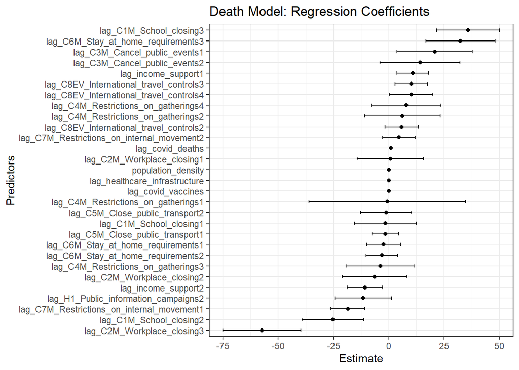

```r
# Extract coefficients
coeffs_death <- tidy(reg_model_death, conf.int = TRUE) %>%
  filter(term != "(Intercept)")

# Plot coefficients
ggplot(coeffs_death, aes(x = reorder(term, estimate), y = estimate)) +
  geom_point() +
  geom_errorbar(aes(ymin = conf.low, ymax = conf.high), width = 0.3) +
  coord_flip() +  # Flip for easier reading
  labs(title = "Death Model: Regression Coefficients", x = "Predictors", y = "Estimate") +
  theme_bw()
```